# IODS course project

# Logistic Analysis - week 3

*I have learned how to merge datasets from R, apply logistic regression, interpret its output, predict power of the model and conduct cross-validation.*

## Task 2

```r
setwd("D:/New folder/OneDrive for Business 1/Git/IODS/IODS-project/data")

alc <- read.table(file = "alc.txt",
                           header = TRUE,
                           dec = ".")
```

### Libraries

```r
library(tidyr)
library(dplyr)
```

```r
library(ggplot2)
library(GGally)
```

### Structure

```r
str(alc)
```

```
## 'data.frame':    382 obs. of  35 variables:
##  $ school    : Factor w/ 2 levels "GP","MS": 1 1 1 1 1 1 1 1 1 1 ...
##  $ sex       : Factor w/ 2 levels "F","M": 1 1 1 1 1 2 2 1 2 2 ...
##  $ age       : int  18 17 15 15 16 16 16 17 15 15 ...
##  $ address   : Factor w/ 2 levels "R","U": 2 2 2 2 2 2 2 2 2 2 ...
##  $ famsize   : Factor w/ 2 levels "GT3","LE3": 1 1 2 1 1 2 2 1 2 1 ...
##  $ Pstatus   : Factor w/ 2 levels "A","T": 1 2 2 2 2 2 2 1 1 2 ...
##  $ Medu      : int  4 1 1 4 3 4 2 4 3 3 ...
##  $ Fedu      : int  4 1 1 2 3 3 2 4 2 4 ...
##  $ Mjob      : Factor w/ 5 levels "at_home","health",..: 1 1 1 2 3 4 3 3 4 3 ...
##  $ Fjob      : Factor w/ 5 levels "at_home","health",..: 5 3 3 4 3 3 3 5 3 3 ...
##  $ reason    : Factor w/ 4 levels "course","home",..: 1 1 3 2 2 4 2 2 2 2 ...
##  $ nursery   : Factor w/ 2 levels "no","yes": 2 1 2 2 2 2 2 2 2 2 ...
##  $ internet  : Factor w/ 2 levels "no","yes": 1 2 2 2 1 2 2 1 2 2 ...
##  $ guardian  : Factor w/ 3 levels "father","mother",..: 2 1 2 2 1 2 2 2 2 2 ...
```

[output cut: 21 more lines]

```r
names(alc)
```

```
##  [1] "school"     "sex"        "age"        "address"    "famsize"
##  [6] "Pstatus"    "Medu"       "Fedu"       "Mjob"       "Fjob"
## [11] "reason"     "nursery"    "internet"   "guardian"   "traveltime"
## [16] "studytime"  "failures"   "schoolsup"  "famsup"     "paid"
## [21] "activities" "higher"     "romantic"   "famrel"     "freetime"
## [26] "goout"      "Dalc"       "Walc"       "health"     "absences"
## [31] "G1"         "G2"         "G3"         "alc_use"    "high_use"
```

This data approach alcohol consumption by students in secondary education of two Portuguese schools. The data attributes include student grades, demographic, social and school related features, and it was collected by using school reports and questionnaires. The response variable (high_use) is binary, and according to hypotheses four covariates were chosen to model its probability: 1-“address” (factor with 2 levels), “freetime” (integer), “sex” (factor with 2 levels) and “failures” (integer). Source: Paulo Cortez, University of Minho, Guimarães, Portugal, http://www3.dsi.uminho.pt/pcortez

## Task 3

### Hypotheses

1.[address] The probability of higher alcohol consumption is higher for students living in rural areas; 2.[free time] The probability of higher alcohol consumption is higher for students with more free time; 3.[sex] The probability of higher alcohol consumption is higher for male students; 4.[failures] The probability of higher alcohol consumption is higher for students with more failures.

## Task 4

### Relationships

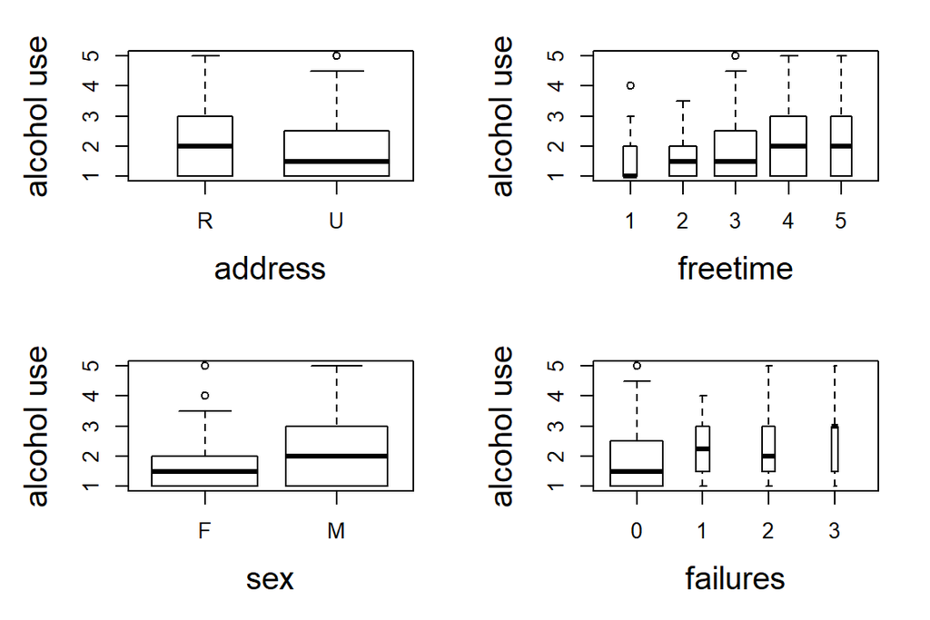

```r
par(mfrow = c(2, 2), mar = c(5, 5, 2, 2), cex.lab = 1.5)
boxplot(alc$alc_use ~ address,
        varwidth = TRUE,
        data = alc,
        xlab     = "address",
        ylab     = "alcohol use")

boxplot(alc$alc_use ~ freetime,
        varwidth = TRUE,
        data = alc,
        xlab     = "freetime",
        ylab     = "alcohol use")

boxplot(alc$alc_use ~ sex,
        varwidth = TRUE,
        data = alc,
        xlab     = "sex",
        ylab     = "alcohol use")

boxplot(alc$alc_use ~ failures,
        varwidth = TRUE,
        data = alc,
        xlab     = "failures",
        ylab     = "alcohol use")
```

On average students living in rural areas drink more than students living in urban areas. Alcohol use seems to increase with the amount of free time. Male students drink on average more than female students. Students who failed at least once seem more likely to drink more alcohol than those who have never failed, but the amount of failures does not seem to matter for alcohol consumption.

## Task 5

### Fit the model

```r
m1 <- glm(high_use ~ address + freetime + failures + sex, data = alc, family = "binomial")
summary(m1)
```

```
##
## Call:
## glm(formula = high_use ~ address + freetime + failures + sex,
##     family = "binomial", data = alc)
##
## Deviance Residuals:
##     Min       1Q   Median       3Q      Max
## -1.6611  -0.8628  -0.6273   1.1944   1.9696
##
## Coefficients:
##             Estimate Std. Error z value Pr(>|z|)
## (Intercept)  -1.8036     0.4622  -3.903 9.52e-05 ***
## addressU     -0.4981     0.2730  -1.824  0.06813 .
## freetime      0.2586     0.1226   2.109  0.03494 *
## failures      0.4563     0.1881   2.425  0.01530 *
## sexM          0.7293     0.2393   3.048  0.00231 **
## ---
## Signif. codes:  0 '***' 0.001 '**' 0.01 '*' 0.05 '.' 0.1 ' ' 1
##
## (Dispersion parameter for binomial family taken to be 1)
##
##     Null deviance: 465.68  on 381  degrees of freedom
## Residual deviance: 436.39  on 377  degrees of freedom
## AIC: 446.39
##
## Number of Fisher Scoring iterations: 4
```

```r
drop1(m1, test="Chi")
```

```
## Single term deletions
##
## Model:
## high_use ~ address + freetime + failures + sex
##          Df Deviance    AIC    LRT Pr(>Chi)
## <none>        436.39 446.39
## address   1   439.66 447.66 3.2647 0.070785 .
## freetime  1   440.94 448.94 4.5497 0.032924 *
## failures  1   442.37 450.37 5.9730 0.014527 *
## sex       1   445.83 453.83 9.4358 0.002128 **
## ---
## Signif. codes:  0 '***' 0.001 '**' 0.01 '*' 0.05 '.' 0.1 ' ' 1
```

Students living in urban areas tend to have lower probability of high alcohol consumption, but as the significance is borderline we drop this covariate. The probability of high alcohol consumption is higher for students with more freetime and failures, as well as for guys compared to girls.

```r
m2 <- glm(high_use ~ freetime + failures + sex, data = alc, family = "binomial")
summary(m2)
```

```
##
## Call:
## glm(formula = high_use ~ freetime + failures + sex, family = "binomial",
##     data = alc)
##
## Deviance Residuals:
##     Min       1Q   Median       3Q      Max
## -1.7236  -0.9035  -0.6594   1.2548   1.9179
##
## Coefficients:
##             Estimate Std. Error z value Pr(>|z|)
## (Intercept)  -2.1678     0.4227  -5.128 2.93e-07 ***
## freetime      0.2509     0.1224   2.049  0.04047 *
## failures      0.4696     0.1887   2.489  0.01280 *
## sexM          0.7333     0.2379   3.083  0.00205 **
## ---
## Signif. codes:  0 '***' 0.001 '**' 0.01 '*' 0.05 '.' 0.1 ' ' 1
##
## (Dispersion parameter for binomial family taken to be 1)
##
##     Null deviance: 465.68  on 381  degrees of freedom
## Residual deviance: 439.66  on 378  degrees of freedom
## AIC: 447.66
##
## Number of Fisher Scoring iterations: 4
```

- Probability of high consumption for females pi_i =exp(-2.1678 + 0.2509*freetime_i + 0.4696*failures_i) / 1 + exp(-2.1678 + 0.2509*freetime_i + 0.4696*failures_i)
- Probability of high consumption for males pi_i =exp(-2.1678 + 0.7333 + 0.2509*freetime_i + 0.4696*failures_i) / 1 + exp(-2.1678 + 0.7333 + 0.2509*freetime_i + 0.4696*failures_i)

### odds ratios (OR)

```r
OR<- coef(m2) %>% exp
```

### confidence intervals (CI)

```r
CI<-confint(m2) %>%exp
```

### odds ratios with their confidence intervals

```r
cbind(OR, CI)
```

```
##                    OR      2.5 %    97.5 %
## (Intercept) 0.1144314 0.04877352 0.2566447
## freetime    1.2851542 1.01340677 1.6394937
## failures    1.5993597 1.10852255 2.3355716
## sexM        2.0818977 1.30990347 3.3338243
```

Odds are all higher than 1, meaning that all covariates are positively associated with high alcohol consumption.

## Task 6

### Predictive power of model

```r
probabilities <- predict(m2, type = "response")
alc <- mutate(alc, probability = probabilities)
alc <- mutate(alc, prediction=probability>0.5)
```

### tabulate the target variable versus the predictions

```r
table(high_use = alc$high_use, prediction = alc$prediction)
```

```
##         prediction
## high_use FALSE TRUE
##    FALSE   259    9
##    TRUE    100   14
```

```r
table(high_use = alc$high_use, prediction = alc$prediction)%>%prop.table()%>%addmargins()
```

```
##         prediction
## high_use      FALSE       TRUE        Sum
##    FALSE 0.67801047 0.02356021 0.70157068
##    TRUE  0.26178010 0.03664921 0.29842932
##    Sum   0.93979058 0.06020942 1.00000000
```

### loss function (mean prediction error)

```r
loss_func <- function(class, prob) {
  n_wrong <- abs(class - prob) > 0.5
  mean(n_wrong)
}
```

### average number of wrong predictions

```r
loss_func(class = alc$high_use, prob = alc$probability)
```

```
## [1] 0.2853403
```

28% of individuals are inaccurately classified by the model (m2)

## Bonus

### K-fold cross-validation

```r
library(boot)
cv1 <- cv.glm(data = alc, cost = loss_func, glmfit = m1, K = 10)
cv1$delta[1]
```

```
## [1] 0.3062827
```

```r
m3 <- glm(high_use ~sex*absences, data = alc, family = "binomial")
summary(m3)
```

```
##
## Call:
## glm(formula = high_use ~ sex * absences, family = "binomial",
##     data = alc)
##
## Deviance Residuals:
##     Min       1Q   Median       3Q      Max
## -1.6717  -0.7558  -0.6473   0.8955   1.8831
##
## Coefficients:
##               Estimate Std. Error z value Pr(>|z|)
## (Intercept)   -1.58688    0.22320  -7.110 1.16e-12 ***
## sexM           0.27803    0.33389   0.833  0.40501
## absences       0.05211    0.02450   2.127  0.03342 *
## sexM:absences  0.14973    0.05093   2.940  0.00328 **
## ---
## Signif. codes:  0 '***' 0.001 '**' 0.01 '*' 0.05 '.' 0.1 ' ' 1
##
## (Dispersion parameter for binomial family taken to be 1)
##
##     Null deviance: 465.68  on 381  degrees of freedom
## Residual deviance: 420.80  on 378  degrees of freedom
## AIC: 428.8
##
## Number of Fisher Scoring iterations: 4
```

```r
cv3 <- cv.glm(data = alc, cost = loss_func, glmfit = m3, K = 10)
cv3$delta[1]
```

```
## [1] 0.2513089
```

A model with an interaction between absences and sex provides smaller prediction error.